# Import Libraries

Import necessary Python libraries including pandas, numpy, matplotlib, and seaborn.

```python
import pandas as pd
import numpy as np
import matplotlib.pyplot as plt
import seaborn as sns
```

# Read CSV Files

```python
# Read CSV files using file paths
flights_df = pd.read_csv("/Users/yuxia/Downloads/Data Challenge/data/Flights.csv", low_memory=False)
tickets_df = pd.read_csv("/Users/yuxia/Downloads/Data Challenge/data/Tickets.csv")
airports_df = pd.read_csv("/Users/yuxia/Downloads/Data Challenge/data/Airport_Codes.csv")
```

# Preview Data Dimensions

```python
print("Flights.csv dimensions:", flights_df.shape)
print("Tickets.csv dimensions:", tickets_df.shape)
print("Airport_Codes.csv dimensions:", airports_df.shape)
```

```
Flights.csv dimensions: (1915886, 16)
Tickets.csv dimensions: (1167285, 12)
Airport_Codes.csv dimensions: (55369, 8)
```

# Data Cleaning

## 1) Data Type Validation

Check and validate data types for all columns in each dataset.

### Step 1: Check data types

```python
print("\nFlights.csv information:")
print(flights_df.info())

print("\nTickets.csv information:")
print(tickets_df.info())

print("\nAirport_Codes.csv information:")
print(airports_df.info())
```

```
Flights.csv information:
<class 'pandas.core.frame.DataFrame'>
RangeIndex: 1915886 entries, 0 to 1915885
Data columns (total 16 columns):
 #   Column             Dtype
---  ------             -----
 0   FL_DATE            object
 1   OP_CARRIER         object
 2   TAIL_NUM           object
 3   OP_CARRIER_FL_NUM  object
 4   ORIGIN_AIRPORT_ID  int64
 5   ORIGIN             object
 6   ORIGIN_CITY_NAME   object
 7   DEST_AIRPORT_ID    int64
 8   DESTINATION        object
 9   DEST_CITY_NAME     object
 10  DEP_DELAY          float64
 11  ARR_DELAY          float64
 12  CANCELLED          float64
 13  AIR_TIME           object
 14  DISTANCE           object
 15  OCCUPANCY_RATE     float64
dtypes: float64(4), int64(2), object(10)
memory usage: 233.9+ MB
None

Tickets.csv information:
<class 'pandas.core.frame.DataFrame'>
RangeIndex: 1167285 entries, 0 to 1167284
Data columns (total 12 columns):
 #   Column             Non-Null Count    Dtype
---  ------             --------------    -----
 0   ITIN_ID            1167285 non-null  int64
 1   YEAR               1167285 non-null  int64
 2   QUARTER            1167285 non-null  int64
 3   ORIGIN             1167285 non-null  object
 4   ORIGIN_COUNTRY     1167285 non-null  object
 5   ORIGIN_STATE_ABR   1167285 non-null  object
 6   ORIGIN_STATE_NM    1167285 non-null  object
 7   ROUNDTRIP          1167285 non-null  float64
```

[output cut: 10 more lines]

```
RangeIndex: 55369 entries, 0 to 55368
Data columns (total 8 columns):
 #   Column        Non-Null Count  Dtype
---  ------        --------------  -----
 0   TYPE          55369 non-null  object
 1   NAME          55369 non-null  object
 2   ELEVATION_FT  48354 non-null  float64
 3   CONTINENT     27526 non-null  object
 4   ISO_COUNTRY   55122 non-null  object
 5   MUNICIPALITY  49663 non-null  object
 6   IATA_CODE     9182 non-null   object
 7   COORDINATES   55369 non-null  object
dtypes: float64(1), object(7)
memory usage: 3.4+ MB
None
```

**Data Quality Issues Summary:**

**Flights:**

`AIR_TIME`, `DISTANCE` are read as object type, suggesting the presence of non-numeric values or missing entries.

`FL_Date` (object) should be datetime64

**Tickets:**

`ITIN_FARE` is identified as an object, but it should be float 64, there might be non-numeric values containing '$'

### Step 2: Convert `FL_DATE` to datetime

```python
# Convert 'FL_DATE' to datetime
flights_df['FL_DATE'] = pd.to_datetime(flights_df['FL_DATE'], errors='coerce')
# Check the converted data type
print("\nFL_DATE data type:", flights_df['FL_DATE'].dtype)
```

```
FL_DATE data type: datetime64[ns]
```

### Step 3: Analyze other non-numeric characters in each field

`AIR_TIME`, `DISTANCE`, `ITIN_FARE`

```python
# Analyze non-numeric characters in each field
# Create a function to extract and analyze non-numeric characters
def analyze_non_numeric(series, column_name):
    print(f"\n=== {column_name} Analysis ===\n")
    str_series = series.astype(str)
    non_numeric = str_series.str.findall(r'[^0-9.-]')
    print("Non-numeric character combinations and their frequencies:")
    char_counts = non_numeric.value_counts().head(10)
    print(char_counts)


# Analyze AIR_TIME
analyze_non_numeric(flights_df['AIR_TIME'], 'AIR_TIME')

# Analyze DISTANCE
analyze_non_numeric(flights_df['DISTANCE'], 'DISTANCE')

# Analyze ITIN_FARE
analyze_non_numeric(tickets_df['ITIN_FARE'], 'ITIN_FARE')
```

```
=== AIR_TIME Analysis ===

Non-numeric character combinations and their frequencies:
AIR_TIME
[]           1857425
[n, a, n]      56551
[$, $, $]       1890
[T, w, o]         10
[N, A, N]         10
Name: count, dtype: int64

=== DISTANCE Analysis ===

Non-numeric character combinations and their frequencies:
DISTANCE
[]                       1913146
[*, *, *, *]                2070
[n, a, n]                    630
[N, A, N]                     20
[H, u, n, d, r, e, d]         10
[T, w, e, n, t, y]            10
Name: count, dtype: int64

=== ITIN_FARE Analysis ===

Non-numeric character combinations and their frequencies:
ITIN_FARE
[]           1163149
[ , $]          1751
[$,  ]          1085
[n, a, n]        960
[$, $, $]        340
Name: count, dtype: int64
```

From our analysis of non-numeric characters, we need to:

1. Normalize all representations of missing data (e.g., “nan”, “NAN”).
2. Translate spelled-out numbers (like “Hundred” or “Twenty”) into their numeric equivalents.
3. Strip out currency symbols and excess whitespace.
4. Flag and clean any truly anomalous entries (for instance, fields containing “*”).

### Step 4: Data Cleaning

Implementation of a comprehensive data cleaning function to handle various types of non-numeric characters and inconsistencies in numeric columns.

```python
# Define a cleaning function to handle all types of non-numeric characters
def clean_numeric_column(df, column_name):
    # Convert data to strings
    series = df[column_name].astype(str)

    # Replace text numbers
    number_map = {'Two': '2', 'Twenty': '20', 'Hundred': '100'}
    for word, num in number_map.items():
        series = series.str.replace(word, num)

    # Handle $ symbol, spaces, and NAN values
    series = series.str.replace('$', '').str.strip()
    series = series.replace(['nan', 'NAN', '*', '***', '****'], pd.NA)

    df[column_name] = pd.to_numeric(series, errors='coerce')
    return df

flights_df = clean_numeric_column(flights_df, 'AIR_TIME')
flights_df = clean_numeric_column(flights_df, 'DISTANCE')
tickets_df = clean_numeric_column(tickets_df, 'ITIN_FARE')

# Check the results after cleaning
def check_cleaned_data(df, column_name):
    print(f"\n=== {column_name} Post-Cleaning Statistics ===")
    print("Data type:", df[column_name].dtype)
    total = len(df)
    missing = df[column_name].isna().sum()
    missing_ratio = missing / total * 100

    print(f"Total data points: {total}")
    print(f"Missing values: {missing}")
    print(f"Missing value percentage: {missing_ratio:.2f}%")

check_cleaned_data(flights_df, 'AIR_TIME')
check_cleaned_data(flights_df, 'DISTANCE')
check_cleaned_data(tickets_df, 'ITIN_FARE')
```

```
=== AIR_TIME Post-Cleaning Statistics ===
Data type: float64
Total data points: 1915886
Missing values: 58451
Missing value percentage: 3.05%

=== DISTANCE Post-Cleaning Statistics ===
Data type: float64
Total data points: 1915886
Missing values: 2720
Missing value percentage: 0.14%

=== ITIN_FARE Post-Cleaning Statistics ===
Data type: float64
Total data points: 1167285
Missing values: 960
Missing value percentage: 0.08%
```

## 2) Data Preparation

### 1. Filter Business-relevant Data

- Apply business logic filters to focus on relevant data: exclude cancelled flights, keep only roundtrip tickets, and filter for medium/large US airports.

```python
flights_df = flights_df[flights_df['CANCELLED'] != 1]
tickets_df = tickets_df[tickets_df['ROUNDTRIP'] == 1]
airports_df = airports_df[
    (airports_df['TYPE'].isin(['medium_airport', 'large_airport'])) &
    (airports_df['ISO_COUNTRY'] == 'US')]

print(f"After filtering:")
print(f"Non-cancelled flights: {flights_df.shape}")
print(f"Roundtrip tickets: {tickets_df.shape}")
print(f"Medium and large airports in US: {airports_df.shape}")
```

```
After filtering:
Non-cancelled flights: (1864272, 16)
Roundtrip tickets: (708600, 12)
Medium and large airports in US: (858, 8)
```

### 2. Numeric Columns Statistics Analysis

```python
def analyze_numeric_dataset(df, name):
    print(f"\n{name} - Numeric Columns Statistics:")
    print(df.describe(include=[np.number]).T)

analyze_numeric_dataset(tickets_df, "Tickets Dataset")
analyze_numeric_dataset(flights_df, "Flights Dataset")
analyze_numeric_dataset(airports_df, "Airport Codes Dataset")
```

```
Tickets Dataset - Numeric Columns Statistics:
               count          mean           std        min           25%  \
ITIN_ID     708600.0  1.733027e+11  6.682374e+10  2019119.0  2.019116e+11
YEAR        708600.0  2.019000e+03  0.000000e+00     2019.0  2.019000e+03
QUARTER     708600.0  1.000000e+00  0.000000e+00        1.0  1.000000e+00
ROUNDTRIP   708600.0  1.000000e+00  0.000000e+00        1.0  1.000000e+00
PASSENGERS  707403.0  1.936837e+00  5.040905e+00        1.0  1.000000e+00
ITIN_FARE   708040.0  4.733822e+02  3.442245e+02        0.0  2.790000e+02

                     50%           75%           max
ITIN_ID     2.019128e+11  2.019140e+11  2.019153e+11
YEAR        2.019000e+03  2.019000e+03  2.019000e+03
QUARTER     1.000000e+00  1.000000e+00  1.000000e+00
ROUNDTRIP   1.000000e+00  1.000000e+00  1.000000e+00
PASSENGERS  1.000000e+00  1.000000e+00  6.810000e+02
ITIN_FARE   4.160000e+02  5.960000e+02  3.840000e+04

Flights Dataset - Numeric Columns Statistics:
                       count          mean          std      min       25%  \
ORIGIN_AIRPORT_ID  1864272.0  12685.801078  1522.326034  10135.0  11292.00
DEST_AIRPORT_ID    1864272.0  12687.102740  1521.973144  10135.0  11292.00
DEP_DELAY          1864272.0     10.769916    50.069236    -63.0     -6.00
ARR_DELAY          1859895.0      5.648737    52.411696    -94.0    -15.00
CANCELLED          1864272.0      0.000000     0.000000      0.0      0.00
AIR_TIME           1857425.0    109.386105    70.469259   -121.0     59.00
DISTANCE           1861612.0    772.368097   582.680709  -1947.0    344.00
OCCUPANCY_RATE     1863962.0      0.650241     0.202002      0.3      0.48

                        50%       75%      max
ORIGIN_AIRPORT_ID  12889.00  14057.00  16218.0
DEST_AIRPORT_ID    12889.00  14057.00  16218.0
DEP_DELAY             -2.00      7.00   2941.0
ARR_DELAY             -6.00      8.00   2923.0
CANCELLED              0.00      0.00      0.0
AIR_TIME              91.00    139.00   2222.0
DISTANCE             612.00   1013.00   9898.0
OCCUPANCY_RATE         0.65      0.83      1.0

Airport Codes Dataset - Numeric Columns Statistics:
              count         mean          std    min   25%    50%     75%  \
ELEVATION_FT  855.0  1166.203509  1613.551043 -115.0  97.5  559.0  1290.0

                 max
ELEVATION_FT  7820.0
```

## 3) Outlier Analysis

**Objective**: Identify and analyze outliers in numerical columns across all datasets using IQR method and visualizations to ensure data quality

### Step 1: Outlier Detection and Analysis

1. **Statistical Analysis**
2. **IQR-based Outlier Detection**
   - Q1 (25th percentile) and Q3 (75th percentile)
   - Interquartile Range (IQR = Q3 - Q1)
   - Outlier boundaries: Lower = Q1 - 1.5×IQR, Upper = Q3 + 1.5×IQR
   - Count and calculate percentage of outliers beyond these boundaries
3. **Visual Analysis**
   - Generate box plots to visualize data distribution and outlier positions
   - Create scatter plots for correlated variables (AIR_TIME vs DISTANCE)
4. **Correlation Assessment**
   - Calculate correlation coefficients between related variables
   - Validate logical relationships (e.g., longer distances should correlate with longer air times)

```
==================================================
Checking outliers for AIR_TIME
==================================================

1. Basic Statistics:
count    1.857425e+06
mean     1.093861e+02
std      7.046926e+01
min     -1.210000e+02
25%      5.900000e+01
50%      9.100000e+01
75%      1.390000e+02
max      2.222000e+03
Name: AIR_TIME, dtype: float64

2. Box Plot Rule Outliers:
Lower bound: -61.00
Upper bound: 259.00
Number of outliers: 93990
Outlier percentage: 5.04%
```

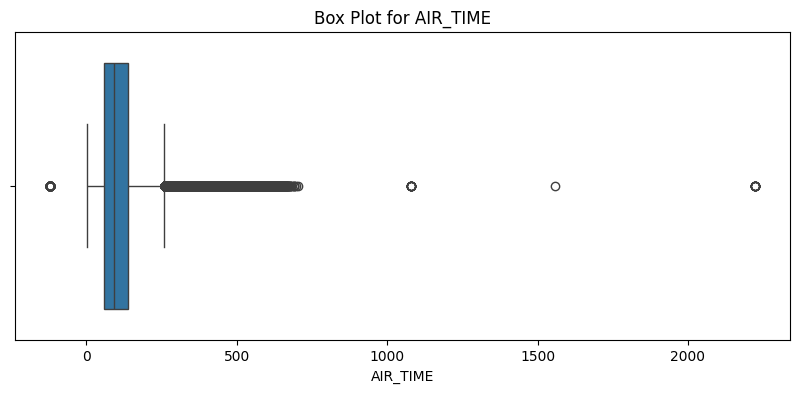

```
3. Correlation between AIR_TIME and DISTANCE: 0.97
```

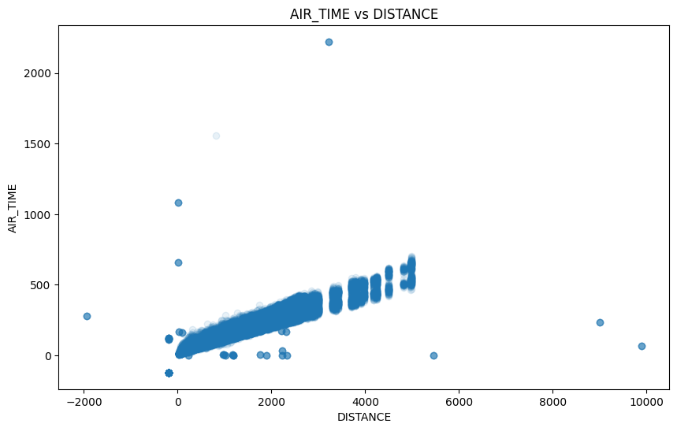

```
==================================================
Checking outliers for DISTANCE
==================================================

1. Basic Statistics:
count    1.861612e+06
mean     7.723681e+02
std      5.826807e+02
min     -1.947000e+03
25%      3.440000e+02
50%      6.120000e+02
75%      1.013000e+03
max      9.898000e+03
Name: DISTANCE, dtype: float64

2. Box Plot Rule Outliers:
Lower bound: -659.50
Upper bound: 2016.50
Number of outliers: 98921
Outlier percentage: 5.31%
```

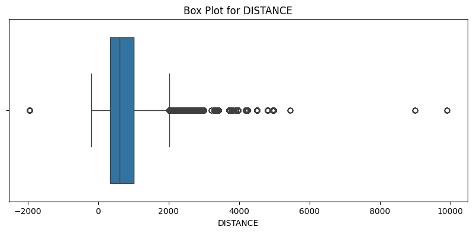

```
3. Correlation between AIR_TIME and DISTANCE: 0.97
```

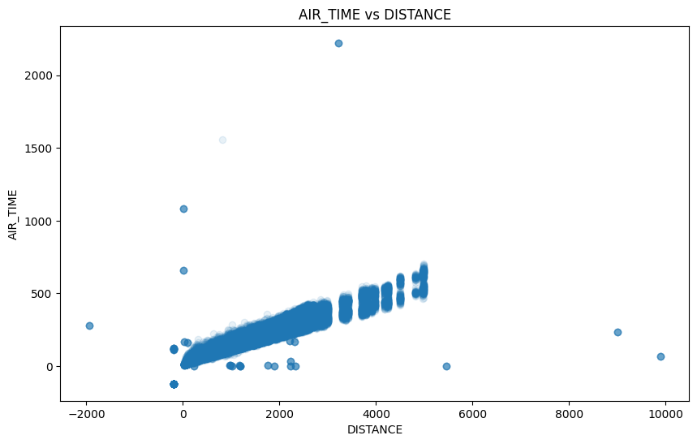

```
==================================================
Checking outliers for DEP_DELAY
==================================================

1. Basic Statistics:
count    1.864272e+06
mean     1.076992e+01
std      5.006924e+01
min     -6.300000e+01
25%     -6.000000e+00
50%     -2.000000e+00
75%      7.000000e+00
max      2.941000e+03
Name: DEP_DELAY, dtype: float64

2. Box Plot Rule Outliers:
Lower bound: -25.50
Upper bound: 26.50
Number of outliers: 246198
Outlier percentage: 13.21%
```

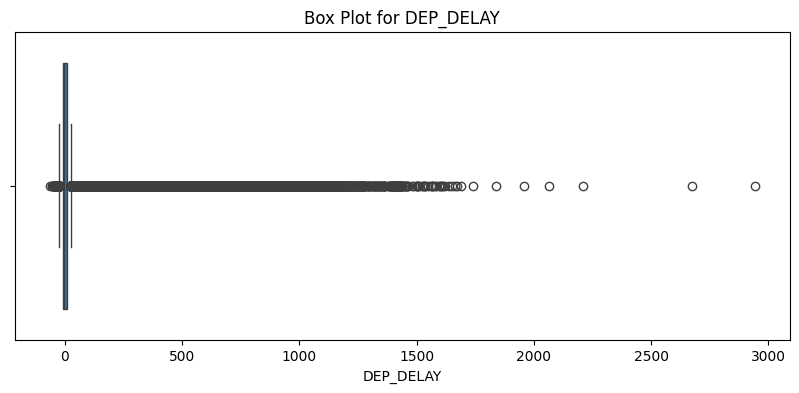

```
==================================================
Checking outliers for ARR_DELAY
==================================================

1. Basic Statistics:
count    1.859895e+06
mean     5.648737e+00
std      5.241170e+01
min     -9.400000e+01
25%     -1.500000e+01
50%     -6.000000e+00
75%      8.000000e+00
max      2.923000e+03
Name: ARR_DELAY, dtype: float64

2. Box Plot Rule Outliers:
Lower bound: -49.50
Upper bound: 42.50
Number of outliers: 174812
Outlier percentage: 9.38%
```

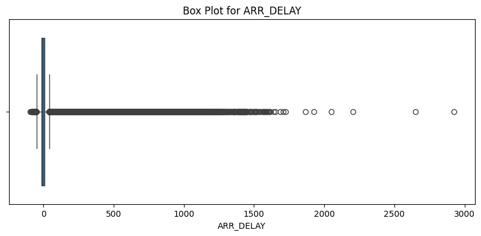

```
==================================================
Checking outliers for ITIN_FARE
==================================================

1. Basic Statistics:
count    708040.000000
mean        473.382224
std         344.224485
min           0.000000
25%         279.000000
50%         416.000000
75%         596.000000
max       38400.000000
Name: ITIN_FARE, dtype: float64

2. Box Plot Rule Outliers:
Lower bound: -196.50
Upper bound: 1071.50
Number of outliers: 30688
Outlier percentage: 4.33%
```

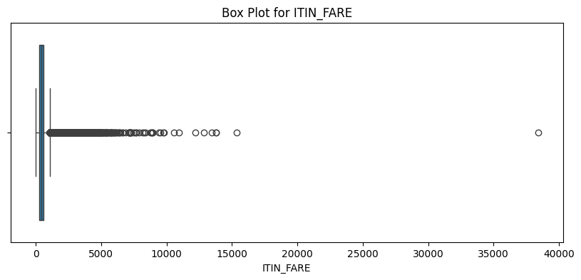

```
==================================================
Checking outliers for PASSENGERS
==================================================

1. Basic Statistics:
count    707403.000000
mean          1.936837
std           5.040905
min           1.000000
25%           1.000000
50%           1.000000
75%           1.000000
max         681.000000
Name: PASSENGERS, dtype: float64

2. Box Plot Rule Outliers:
Lower bound: 1.00
Upper bound: 1.00
Number of outliers: 152264
Outlier percentage: 21.49%
```

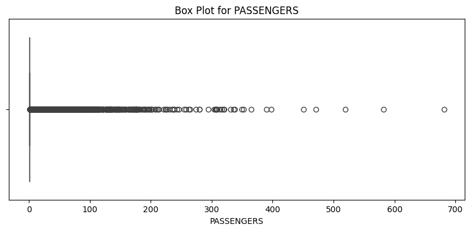

```
==================================================
Checking outliers for ELEVATION_FT
==================================================

1. Basic Statistics:
count     855.000000
mean     1166.203509
std      1613.551043
min      -115.000000
25%        97.500000
50%       559.000000
75%      1290.000000
max      7820.000000
Name: ELEVATION_FT, dtype: float64

2. Box Plot Rule Outliers:
Lower bound: -1691.25
Upper bound: 3078.75
Number of outliers: 106
Outlier percentage: 12.35%
```

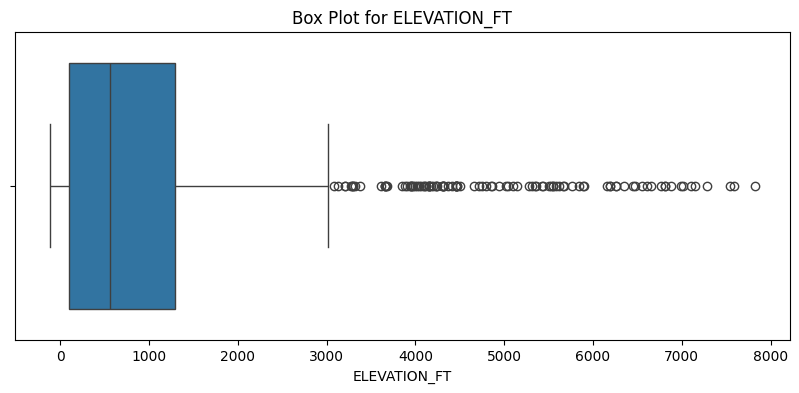

```python
def check_outliers_comprehensive(df, columns):
    for col in columns:
        print(f"\n{'='*50}")
        print(f"Checking outliers for {col}")
        print(f"{'='*50}")

        # 1. Basic statistics
        print("\n1. Basic Statistics:")
        stats = df[col].describe()
        print(stats)

        # 2. Box plot analysis
        Q1 = stats['25%']
        Q3 = stats['75%']
        IQR = Q3 - Q1
        lower_bound = Q1 - 1.5 * IQR
        upper_bound = Q3 + 1.5 * IQR

        outliers = df[(df[col] < lower_bound) | (df[col] > upper_bound)][col]
        print(f"\n2. Box Plot Rule Outliers:")
        print(f"Lower bound: {lower_bound:.2f}")
        print(f"Upper bound: {upper_bound:.2f}")
        print(f"Number of outliers: {len(outliers)}")
        print(f"Outlier percentage: {(len(outliers)/len(df)*100):.2f}%")

        plt.figure(figsize=(10, 4))
        sns.boxplot(x=df[col])
        plt.title(f'Box Plot for {col}')
        plt.show()

        # 3. Correlation check (for specific columns)
        if col in ['AIR_TIME', 'DISTANCE'] and 'AIR_TIME' in df.columns and 'DISTANCE' in df.columns:
            correlation = df['AIR_TIME'].corr(df['DISTANCE'])
            print(f"\n3. Correlation between AIR_TIME and DISTANCE: {correlation:.2f}")

            plt.figure(figsize=(10, 6))
            plt.scatter(df['DISTANCE'], df['AIR_TIME'], alpha=0.1)
            plt.xlabel('DISTANCE')
            plt.ylabel('AIR_TIME')
            plt.title('AIR_TIME vs DISTANCE')
            plt.show()


columns_to_check = ['AIR_TIME', 'DISTANCE', 'DEP_DELAY', 'ARR_DELAY']
check_outliers_comprehensive(flights_df, columns_to_check)
columns_to_check = ['ITIN_FARE', 'PASSENGERS']
check_outliers_comprehensive(tickets_df, columns_to_check)
columns_to_check = ['ELEVATION_FT']
check_outliers_comprehensive(airports_df, columns_to_check)
```

### Step 2: Outlier Handling

**Outlier Removal Summary:**

- Air_Time

> Negative values: physically impossible flight times

> 600 minutes: unrealistic for US domestic flights (max should be ~8-9 hours)

Therefore, I will remove the value below 0 and > 600 mins.

- DISTANCE

> Negative Distances: At least one record shows –2,000 miles, clearly a data error.

> Excessive Distances: Several entries fall between 8,000–10,000 miles, far beyond the maximum U.S. domestic span (~3,000 miles).
- Dep_Delay

> Some delays exceed 2,000 minutes (33+ hours), likely due to weather, mechanical issues, or cancellations.

> Rather than deleting these, I’ll add a binary flag DELAY_OUTLIER so we can analyze them separately—long delays can reflect genuine operational disruptions.
- Itin_Fare

> One fare spikes around $38,400, well above typical ticket prices. Possible explanations include premium cabins, complex multi-leg itineraries, or data entry errors.

> I’ll retain this record but flag any fare > $5,000 with FARE_OUTLIER and pass those to the business team for validation instead of deleting them.
- Passengers

> Passengers cannot exceed 200 per flight, as the maximum capacity is 200 people, so records with more than 200 passengers should be filtered out.

```python
print("=== Outlier Handling: Remove Invalid Data Only ===")

# Handle AIR_TIME: Remove only negative values, keep missing values
negative_count = (flights_df['AIR_TIME'] < 0).sum()
flights_df = flights_df[(flights_df['AIR_TIME'] >= 0) | (flights_df['AIR_TIME'].isna())]
print(f"Removed negative AIR_TIME records: {negative_count:,}")

extreme_count = (flights_df['AIR_TIME'] > 600).sum()
flights_df = flights_df[(flights_df['AIR_TIME'] <= 600) | (flights_df['AIR_TIME'].isna())]
print(f"Removed AIR_TIME > 10 hours records: {extreme_count:,}")

# Handle PASSENGERS: Remove only values > 200, keep missing values
outliers = len(tickets_df[(tickets_df['PASSENGERS'] > 200) & (tickets_df['PASSENGERS'].notna())])
print(f"Removing anomalous PASSENGERS records: {outliers} rows")
tickets_df = tickets_df[(tickets_df['PASSENGERS'] <= 200) | (tickets_df['PASSENGERS'].isna())]

# Handle DISTANCE: Remove only negative values, keep missing values
negative_dist = (flights_df['DISTANCE'] < 0).sum()
flights_df = flights_df[(flights_df['DISTANCE'] >= 0) | (flights_df['DISTANCE'].isna())]
print(f"Removed negative DISTANCE records: {negative_dist:,}")

extreme_dist = (flights_df['DISTANCE'] > 3500).sum()
flights_df = flights_df[(flights_df['DISTANCE'] <= 3500) | (flights_df['DISTANCE'].isna())]
print(f"Removed DISTANCE > 3,500 miles records: {extreme_dist:,}")

# Handle delay outliers: Flag only, don't remove missing values
dep_lower_bound = -25.50
dep_upper_bound = 26.50
arr_lower_bound = -49.50
arr_upper_bound = 42.50

# Create outlier flags - missing values will be False (not flagged as outliers)
flights_df['DEP_DELAY_OUTLIER'] = ((flights_df['DEP_DELAY'] < dep_lower_bound) |
                                   (flights_df['DEP_DELAY'] > dep_upper_bound)).fillna(False).astype(int)
flights_df['ARR_DELAY_OUTLIER'] = ((flights_df['ARR_DELAY'] < arr_lower_bound) |
                                   (flights_df['ARR_DELAY'] > arr_upper_bound)).fillna(False).astype(int)

dep_outliers = flights_df['DEP_DELAY_OUTLIER'].sum()
arr_outliers = flights_df['ARR_DELAY_OUTLIER'].sum()
total_flights = len(flights_df)
print(f"Departure delay outliers flagged: {dep_outliers:,} ({dep_outliers/total_flights*100:.2f}%)")
print(f"Arrival delay outliers flagged: {arr_outliers:,} ({arr_outliers/total_flights*100:.2f}%)")

# Handle fare outliers: Flag only, keep missing values
high_fare_threshold = 5000
tickets_df['FARE_OUTLIER'] = ((tickets_df['ITIN_FARE'] > high_fare_threshold) &
                              (tickets_df['ITIN_FARE'].notna())).astype(int)
high_fare_count = tickets_df['FARE_OUTLIER'].sum()
total_tickets = len(tickets_df)
print(f"High-fare tickets flagged (>${high_fare_threshold:,}): {high_fare_count:,} ({high_fare_count/total_tickets*100:.2f}%)")
```

```
=== Outlier Handling: Remove Invalid Data Only ===
Removed negative AIR_TIME records: 100
Removed AIR_TIME > 10 hours records: 255
Removing anomalous PASSENGERS records: 50 rows
Removed negative DISTANCE records: 120
Removed DISTANCE > 3,500 miles records: 2,032
Departure delay outliers flagged: 245,943 (13.21%)
Arrival delay outliers flagged: 174,512 (9.37%)
High-fare tickets flagged (>$5,000): 93 (0.01%)
```

### Airport Code Coverage Analysis

```python
print("Airport Code Coverage Analysis")
print("="*50)

# Get unique airports from each dataset
airports_set = set(airports_df['IATA_CODE'].dropna())
flights_set = set(flights_df['ORIGIN']) | set(flights_df['DESTINATION'])
tickets_set = set(tickets_df['ORIGIN']) | set(tickets_df['DESTINATION'])

print(f"Airports in dataset: {len(airports_set)}")
print(f"Flights airports: {len(flights_set)}")
print(f"Tickets airports: {len(tickets_set)}")

# Calculate coverage rates
flights_coverage = len(flights_set & airports_set) / len(flights_set) * 100
tickets_coverage = len(tickets_set & airports_set) / len(tickets_set) * 100

print(f"\nCoverage rates:")
print(f"Flights: {flights_coverage:.1f}%")
print(f"Tickets: {tickets_coverage:.1f}%")

# Show missing airports
missing_flights = flights_set - airports_set
missing_tickets = tickets_set - airports_set

if missing_flights or missing_tickets:
    print(f"\nMissing airports:")
    if missing_flights:
        print(f"From flights ({len(missing_flights)}): {sorted(missing_flights)}")
    if missing_tickets:
        print(f"From tickets ({len(missing_tickets)}): {sorted(missing_tickets)}")
```

```
Airport Code Coverage Analysis
==================================================
Airports in dataset: 821
Flights airports: 361
Tickets airports: 412

Coverage rates:
Flights: 93.1%
Tickets: 90.8%

Missing airports:
From flights (25): ['ATW', 'BQN', 'CNY', 'DRO', 'DVL', 'EAR', 'ESC', 'GUC', 'GUM', 'HDN', 'HHH', 'IMT', 'MKG', 'MMH', 'OGS', 'PGD', 'PPG', 'PSE', 'PUB', 'SHD', 'SJU', 'SPN', 'STT', 'STX', 'USA']
From tickets (38): ['AIA', 'ATW', 'BQN', 'CEZ', 'CNY', 'CPX', 'CVN', 'DRO', 'DVL', 'EAR', 'ESC', 'GUC', 'GUM', 'HDN', 'HHH', 'IMT', 'MAZ', 'MKG', 'MMH', 'MVY', 'MWA', 'OGS', 'PGD', 'PPG', 'PSE', 'PUB', 'PVC', 'RKD', 'SHD', 'SJU', 'SOW', 'SPN', 'STT', 'STX', 'TEX', 'TVF', 'USA', 'VQS']
```

The results shows that most of the airports in the flights and tickets dataset are within the airport dataset. Therefore, we could generate route_id without worrying too much about losing data.

# Generate Route_ID

- By this steps, we could use route_id as an important factor to handle the missing values in the upcoming process.

```python
# 1. Get IATA code list for medium/large airports
medium_large_airports = set(airports_df['IATA_CODE'].tolist())
print(f"Number of medium/large airports: {len(medium_large_airports)}")

# 2. Filter flights table to keep only flights between medium/large airports
print(f"\nFlights data before filtering: {flights_df.shape[0]}")
flights_df = flights_df[
    (flights_df['ORIGIN'].isin(medium_large_airports)) &
    (flights_df['DESTINATION'].isin(medium_large_airports))
]
print(f"Flights data after filtering: {flights_df.shape[0]}")

# 3. Filter tickets table to keep only tickets between medium/large airports
print(f"\nTickets data before filtering: {tickets_df.shape[0]}")
tickets_df = tickets_df[
    (tickets_df['ORIGIN'].isin(medium_large_airports)) &
    (tickets_df['DESTINATION'].isin(medium_large_airports))
]
print(f"Tickets data after filtering: {tickets_df.shape[0]}")

# 4. Generate ROUTE_ID (based on filtered data)
def generate_route_id(df, name):
    orig, dest = df['ORIGIN'], df['DESTINATION']
    df['ROUTE_ID'] = np.where(
        orig < dest,
        orig + '-' + dest,
        dest + '-' + orig
    )
    print(f"\n{name} after generating ROUTE_ID:")
    print(f"Number of unique routes: {df['ROUTE_ID'].nunique()}")
    print(f"ROUTE_ID examples:")
    print(df[['ORIGIN', 'DESTINATION', 'ROUTE_ID']].head(3))

generate_route_id(flights_df, 'Flights')
generate_route_id(tickets_df, 'Tickets')

# 5. Validate filtering results
print(f"All airports in flights table are in medium/large airport list: {flights_df['ORIGIN'].isin(medium_large_airports).all() and flights_df['DESTINATION'].isin(medium_large_airports).all()}")
print(f"All airports in tickets table are in medium/large airport list: {tickets_df['ORIGIN'].isin(medium_large_airports).all() and tickets_df['DESTINATION'].isin(medium_large_airports).all()}")
```

```
Number of medium/large airports: 822

Flights data before filtering: 1861765
Flights data after filtering: 1830127

Tickets data before filtering: 708550
Tickets data after filtering: 684158

Flights after generating ROUTE_ID:
Number of unique routes: 2816
ROUTE_ID examples:
  ORIGIN DESTINATION ROUTE_ID
0    RSW         CLE  CLE-RSW
1    RSW         CMH  CMH-RSW
2    RSW         CMH  CMH-RSW

Tickets after generating ROUTE_ID:
Number of unique routes: 24045
ROUTE_ID examples:
  ORIGIN DESTINATION ROUTE_ID
0    ABI         DAB  ABI-DAB
1    ABI         COS  ABI-COS
2    ABI         MCO  ABI-MCO
All airports in flights table are in medium/large airport list: True
All airports in tickets table are in medium/large airport list: True
```

## 4) Missing Value Analysis

- Identify and analyze missing values across all datasets.

```
--------------------------------------------------
Flights Dataset Missing Value Analysis
--------------------------------------------------
                Missing Values  Percentage
FL_DATE                   4620        0.25
ARR_DELAY                 4262        0.23
AIR_TIME                  6672        0.36
DISTANCE                  2660        0.15
OCCUPANCY_RATE             310        0.02
```

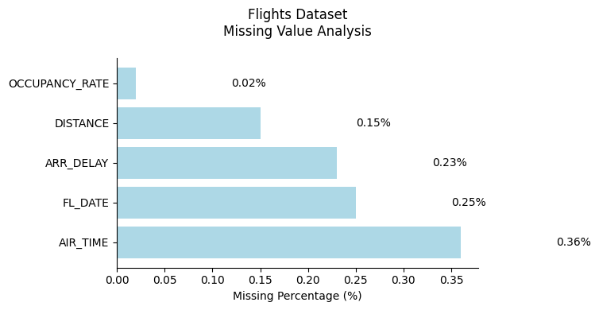

```
--------------------------------------------------
Tickets Dataset Missing Value Analysis
--------------------------------------------------
            Missing Values  Percentage
PASSENGERS            1162        0.17
ITIN_FARE              545        0.08
```

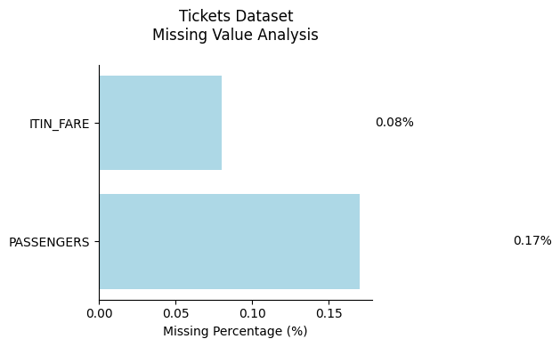

```
--------------------------------------------------
Airports Dataset Missing Value Analysis
--------------------------------------------------
              Missing Values  Percentage
ELEVATION_FT               3        0.35
CONTINENT                858      100.00
MUNICIPALITY               3        0.35
IATA_CODE                 37        4.31
```

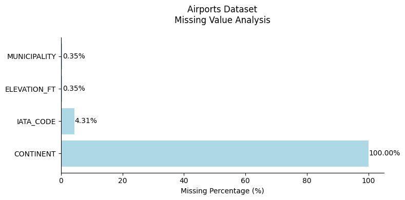

```python
def analyze_missing_values(df, dataset_name):

    print(f"\n{'-'*50}\n{dataset_name} Missing Value Analysis\n{'-'*50}")

    # 1. Basic statistics
    missing_values = df.isnull().sum()
    missing_percentage = (missing_values / len(df)) * 100
    missing_info = pd.DataFrame({
        'Missing Values': missing_values,
        'Percentage': missing_percentage.round(2)
    })
    print(missing_info[missing_info['Missing Values'] > 0])


    # 2. Missing value visualization
    missing_stats = pd.DataFrame({
        'Missing Count': df.isnull().sum(),
        'Missing Percentage': (df.isnull().sum() / len(df) * 100).round(2)
    }).sort_values('Missing Percentage', ascending=False)

    # Keep only columns with missing values
    missing_stats = missing_stats[missing_stats['Missing Count'] > 0]
    missing_percent = missing_stats['Missing Percentage']

    if not missing_percent.empty:
        plt.figure(figsize=(8, max(4, len(missing_percent) * 0.3)))
        bars = plt.barh(y=range(len(missing_percent)), width=missing_percent, color='lightblue')
        plt.yticks(range(len(missing_percent)), missing_percent.index)

        for i, (value, name) in enumerate(zip(missing_percent, missing_percent.index)):
            plt.text(value + 0.1, i, f'{value:.2f}%', va='center')
        plt.title(f'{dataset_name}\nMissing Value Analysis', pad=20)
        plt.xlabel('Missing Percentage (%)')
        plt.gca().spines['top'].set_visible(False)
        plt.gca().spines['right'].set_visible(False)
        plt.tight_layout()
        plt.show()

analyze_missing_values(flights_df, 'Flights Dataset')
analyze_missing_values(tickets_df, 'Tickets Dataset')
analyze_missing_values(airports_df, 'Airports Dataset')
```

**Missing Value Handling Strategy:**

```python
# Handle missing values in a more efficient way
# Function to fill missing values by group median
def fillna_by_group_median(df, col, group_col=None):
    before_na = df[col].isna().sum()

    if group_col and group_col in df.columns:
        # Calculate medians for each group once
        group_medians = df.groupby(group_col)[col].median()
        # Use fillna with a mapping series for better performance
        df[col] = df[col].fillna(df[group_col].map(group_medians))

    after_group_na = df[col].isna().sum()
    if after_group_na > 0:
        df = df[df[col].notna()]
        print(f"{col}: After group median imputation, still {after_group_na} rows missing, all deleted")
    else:
        print(f"{col}: All missing values filled with group median (originally {before_na} rows missing)")

    return df

# 1. Handle missing values in Flights dataset
print("=== Flights Dataset Missing Value Handling ===")

# 1) First check and print original missing value counts
for col in ['AIR_TIME', 'DISTANCE']:
    missing_count = flights_df[col].isna().sum()
    print(f"\n{col} original missing value count: {missing_count}")

    # Identify routes with all missing values
    all_missing_routes = flights_df.groupby('ROUTE_ID')[col].apply(lambda x: x.isna().all())
    routes_to_drop = all_missing_routes[all_missing_routes].index

    if len(routes_to_drop) > 0:
        print(f"Found {len(routes_to_drop)} routes with all {col} values missing")
        flights_df = flights_df[~flights_df['ROUTE_ID'].isin(routes_to_drop)]
        print(f"Deleted records from these routes, {flights_df.shape[0]} records remaining")

    # Use same-route median to fill remaining missing values
    flights_df[col] = flights_df.groupby('ROUTE_ID')[col].transform(lambda x: x.fillna(x.median()))
    remaining_missing = flights_df[col].isna().sum()

    if remaining_missing > 0:
        print(f"Warning: Still {remaining_missing} records of {col} cannot be filled, these records may need further processing")

# Continue handling other missing values...
# 1) Delete rows missing FL_DATE and OCCUPANCY_RATE
before = len(flights_df)
flights_df = flights_df.dropna(subset=['FL_DATE', 'OCCUPANCY_RATE'])
after = len(flights_df)
print(f"Deleted {before - after} rows due to missing FL_DATE or OCCUPANCY_RATE")


# 3) Handle DEP_DELAY and ARR_DELAY missing values
delay_corr = flights_df['DEP_DELAY'].corr(flights_df['ARR_DELAY'])
print(f"\nCorrelation between departure delay and arrival delay: {delay_corr:.2f}")

# Fill missing values using the other delay column
dep_filled = flights_df['DEP_DELAY'].isna() & flights_df['ARR_DELAY'].notna()
arr_filled = flights_df['ARR_DELAY'].isna() & flights_df['DEP_DELAY'].notna()
flights_df.loc[dep_filled, 'DEP_DELAY'] = flights_df.loc[dep_filled, 'ARR_DELAY']
flights_df.loc[arr_filled, 'ARR_DELAY'] = flights_df.loc[arr_filled, 'DEP_DELAY']

# Fill remaining missing values with 0
flights_df['DEP_DELAY'].fillna(0, inplace=True)
flights_df['ARR_DELAY'].fillna(0, inplace=True)
print(f"DEP_DELAY and ARR_DELAY missing values all handled (filled with counterpart or 0)")

# 2. Handle missing values in Tickets dataset
print("\n=== Tickets Dataset Missing Value Handling ===")
for col in ['ITIN_FARE', 'PASSENGERS']:
    tickets_df = fillna_by_group_median(tickets_df, col, group_col='ROUTE_ID')

# 3. Handle missing values in Airports dataset
print("\n=== Airports Dataset Missing Value Handling ===")
# Use ISO_COUNTRY to fill CONTINENT
iso_to_continent = airports_df.dropna(subset=['ISO_COUNTRY', 'CONTINENT'])[['ISO_COUNTRY', 'CONTINENT']].drop_duplicates()
iso_to_continent = dict(zip(iso_to_continent['ISO_COUNTRY'], iso_to_continent['CONTINENT']))
airports_df['CONTINENT'] = airports_df.apply(lambda x: iso_to_continent.get(x['ISO_COUNTRY'], x['CONTINENT']), axis=1)
print(f"Used ISO_COUNTRY to fill CONTINENT missing values")

# Delete rows with missing IATA_CODE
before = len(airports_df)
airports_df = airports_df.dropna(subset=['IATA_CODE'])
after = len(airports_df)
print(f"Deleted {before-after} rows due to missing IATA_CODE")

# Keep missing values for other fields, report missing statistics
print("\nKeeping missing values for the following fields:")
for col in ['ISO_COUNTRY', 'ELEVATION_FT', 'MUNICIPALITY']:
    missing_count = airports_df[col].isna().sum()
    missing_percent = (missing_count / len(airports_df)) * 100
    print(f"{col}: {missing_count} rows missing ({missing_percent:.2f}%)")

# 4. Summary of missing values in all datasets
print("\n=== Missing Value Statistics After Processing ===")
print('\nFlights Dataset:')
print(flights_df.isnull().sum()[flights_df.isnull().sum() > 0])
print('\nTickets Dataset:')
print(tickets_df.isnull().sum()[tickets_df.isnull().sum() > 0])
print('\nAirports Dataset:')
print(airports_df.isnull().sum()[airports_df.isnull().sum() > 0])
```

```
=== Flights Dataset Missing Value Handling ===

AIR_TIME original missing value count: 6672
Found 5 routes with all AIR_TIME values missing
Deleted records from these routes, 1830121 records remaining

DISTANCE original missing value count: 2660
Deleted 4620 rows due to missing FL_DATE or OCCUPANCY_RATE

Correlation between departure delay and arrival delay: 0.96
DEP_DELAY and ARR_DELAY missing values all handled (filled with counterpart or 0)

=== Tickets Dataset Missing Value Handling ===
ITIN_FARE: After group median imputation, still 6 rows missing, all deleted
PASSENGERS: After group median imputation, still 5 rows missing, all deleted

=== Airports Dataset Missing Value Handling ===
Used ISO_COUNTRY to fill CONTINENT missing values
Deleted 37 rows due to missing IATA_CODE

Keeping missing values for the following fields:
ISO_COUNTRY: 0 rows missing (0.00%)
ELEVATION_FT: 0 rows missing (0.00%)
MUNICIPALITY: 0 rows missing (0.00%)

=== Missing Value Statistics After Processing ===

Flights Dataset:
Series([], dtype: int64)

Tickets Dataset:
Series([], dtype: int64)

Airports Dataset:
CONTINENT    821
dtype: int64
```

# Table Joining

## Step 1: Data Joining Analysis

**Objective**: Assess the feasibility of combining the three datasets (Flights, Tickets, and Airports) for analysis.

**Evaluation Dimensions**:

1. **Route Overlap** - Check common routes between Flights and Tickets datasets
2. **Time Alignment** - Verify temporal consistency across datasets
3. **Airline Coverage** - Compare airline representation between datasets

**Success Criteria**:

- Route overlap rate >95%
- Complete time period alignment
- Airline coverage >90%

```python
# Data joining analysis
print("Data Joining Analysis")
print("="*50)

# Check route overlap between flights and tickets
common_routes = set(flights_df['ROUTE_ID']) & set(tickets_df['ROUTE_ID'])
print(f"Routes in flights: {flights_df['ROUTE_ID'].nunique()}")
print(f"Routes in tickets: {tickets_df['ROUTE_ID'].nunique()}")
print(f"Common routes: {len(common_routes)} ({len(common_routes)/flights_df['ROUTE_ID'].nunique()*100:.1f}%)")

# Check time periods
flights_df['YEAR'] = flights_df['FL_DATE'].dt.year
flights_df['QUARTER'] = flights_df['FL_DATE'].dt.quarter

print(f"\nTime range - Flights: {flights_df['FL_DATE'].min().strftime('%Y-%m')} to {flights_df['FL_DATE'].max().strftime('%Y-%m')}")
print(f"Time range - Tickets: {tickets_df['YEAR'].min()}-{tickets_df['YEAR'].max()}")

# Check airlines
flights_airlines = set(flights_df['OP_CARRIER'].dropna())
tickets_airlines = set(tickets_df['REPORTING_CARRIER'].dropna())
common_airlines = flights_airlines & tickets_airlines

print(f"\nAirlines - Flights: {len(flights_airlines)}, Tickets: {len(tickets_airlines)}, Common: {len(common_airlines)}")
print("Data ready for joining")
```

```
Data Joining Analysis
==================================================
Routes in flights: 2808
Routes in tickets: 24036
Common routes: 2778 (98.9%)

Time range - Flights: 2019-01 to 2019-03
Time range - Tickets: 2019-2019

Airlines - Flights: 26, Tickets: 21, Common: 20
Data ready for joining
```

## Step 2: Data Aggregation to (YEAR, QUARTER, ROUTE_ID) Granularity

To facilitate subsequent analysis and joining, we will aggregate the raw data to the (YEAR, QUARTER, ROUTE_ID) granularity level. This allows us to:

1. Reduce data volume and improve processing efficiency
2. Eliminate duplicate records for the same route within the same quarter
3. Create a consistent granularity foundation for three-table joining

```python
# Aggregate data by route and quarter
# Flights summary
flights_agg = flights_df.groupby(['YEAR', 'QUARTER', 'ROUTE_ID']).agg({
    'ORIGIN': 'first',
    'DESTINATION': 'first',
    'DISTANCE': 'first',
    'AIR_TIME': 'mean',
    'DEP_DELAY': 'mean',
    'ARR_DELAY': 'mean',
    'CANCELLED': 'sum',
    'OCCUPANCY_RATE': 'mean',
    'FL_DATE': 'count'
}).rename(columns={
    'FL_DATE': 'FLIGHT_COUNT',
    'AIR_TIME': 'AVG_AIR_TIME',
    'DEP_DELAY': 'AVG_DEP_DELAY',
    'ARR_DELAY': 'AVG_ARR_DELAY',
    'CANCELLED': 'TOTAL_CANCELLED',
    'OCCUPANCY_RATE': 'AVG_OCCUPANCY_RATE'
}).reset_index()

# Tickets summary
tickets_agg = tickets_df.groupby(['YEAR', 'QUARTER', 'ROUTE_ID']).agg({
    'ORIGIN': 'first',
    'DESTINATION': 'first',
    'PASSENGERS': 'sum',
    'ITIN_FARE': 'mean',
    'ITIN_ID': 'count'
}).rename(columns={
    'ITIN_ID': 'TICKET_COUNT',
    'PASSENGERS': 'TOTAL_PASSENGERS',
    'ITIN_FARE': 'AVG_FARE'
}).reset_index()

print(f"Flights: {len(flights_df):,} → {len(flights_agg):,}")
print(f"Tickets: {len(tickets_df):,} → {len(tickets_agg):,}")

# Check overlap
common_routes = set(flights_agg['ROUTE_ID']) & set(tickets_agg['ROUTE_ID'])
print(f"Common routes: {len(common_routes):,} ({len(common_routes)/len(flights_agg)*100:.1f}%)")
```

```
Flights: 1,825,501 → 2,808
Tickets: 684,147 → 24,036
Common routes: 2,778 (98.9%)
```

The results shows that after aggretion, the flights and ticket dataset has a super high route coverage rate. the table are ready to be joined.

## Step 3: Three-Table Joining Operation

Join the aggregated Flights, Tickets, and Airports data to form the final analysis dataset. Join keys: (YEAR, QUARTER, ROUTE_ID)

```python
# Three-table join: Flights + Tickets + Airports

# Prepare airport information tables
airports_origin = airports_df[['IATA_CODE', 'NAME', 'TYPE', 'ELEVATION_FT', 'CONTINENT', 'ISO_COUNTRY']].copy()
airports_origin.columns = ['ORIGIN', 'ORIGIN_AIRPORT_NAME', 'ORIGIN_TYPE', 'ORIGIN_ELEVATION', 'ORIGIN_CONTINENT', 'ORIGIN_COUNTRY']

airports_dest = airports_df[['IATA_CODE', 'NAME', 'TYPE', 'ELEVATION_FT', 'CONTINENT', 'ISO_COUNTRY']].copy()
airports_dest.columns = ['DESTINATION', 'DEST_AIRPORT_NAME', 'DEST_TYPE', 'DEST_ELEVATION', 'DEST_CONTINENT', 'DEST_COUNTRY']

# Join Flights + Airports
flights_enhanced = flights_agg.merge(airports_origin, on='ORIGIN', how='left').merge(airports_dest, on='DESTINATION', how='left')

# Join Tickets + Airports
tickets_enhanced = tickets_agg.merge(airports_origin, on='ORIGIN', how='left').merge(airports_dest, on='DESTINATION', how='left')

# Final three-table join
final_dataset = flights_enhanced.merge(tickets_enhanced, on=['ROUTE_ID', 'YEAR', 'QUARTER'], how='inner', suffixes=('_flight', '_ticket'))

# Result statistics
print(f"Final dataset: {len(final_dataset):,} rows × {len(final_dataset.columns)} columns")
print(f"Unique routes: {final_dataset['ROUTE_ID'].nunique():,}")
print(f"Time range: {final_dataset['YEAR'].min()}-{final_dataset['YEAR'].max()} Q{final_dataset['QUARTER'].min()}-Q{final_dataset['QUARTER'].max()}")
print(f"Retention rate relative to Flights aggregated data: {len(final_dataset)/len(flights_agg)*100:.2f}%")
print(f"Retention rate relative to Tickets aggregated data: {len(final_dataset)/len(tickets_agg)*100:.2f}%")

# Display sample
print("\nData sample:")
display_cols = ['ROUTE_ID', 'YEAR', 'QUARTER', 'ORIGIN_flight', 'DESTINATION_flight', 'FLIGHT_COUNT', 'TOTAL_PASSENGERS', 'AVG_OCCUPANCY_RATE']
available_cols = [col for col in display_cols if col in final_dataset.columns]
print(final_dataset[available_cols].head())
```

```
Final dataset: 2,778 rows × 37 columns
Unique routes: 2,778
Time range: 2019-2019 Q1-Q1
Retention rate relative to Flights aggregated data: 98.93%
Retention rate relative to Tickets aggregated data: 11.56%

Data sample:
  ROUTE_ID  YEAR  QUARTER ORIGIN_flight DESTINATION_flight  FLIGHT_COUNT  \
0  ABE-ATL  2019        1           ATL                ABE           434
1  ABE-CLT  2019        1           ABE                CLT           502
2  ABE-DTW  2019        1           ABE                DTW           497
3  ABE-FLL  2019        1           ABE                FLL            40
4  ABE-ORD  2019        1           ABE                ORD           320

   TOTAL_PASSENGERS  AVG_OCCUPANCY_RATE
0              94.0            0.654332
1              52.0            0.661096
2              99.0            0.645392
3             100.0            0.605250
4              39.0            0.649094
```

# Task 1: Busiest Round-trip Route Analysis

Calculate the top 10 busiest routes ranked by round-trip flight count (excluding cancelled flights)

```python
# Task 1: Busiest Round-trip Route Analysis
print("Analyzing busiest round-trip routes")
print("=" * 50)

# Convert one-way flights to round-trip flights
final_dataset['ROUNDTRIP_FLIGHT_COUNT'] = final_dataset['FLIGHT_COUNT'] / 2

top_10_busy = final_dataset.sort_values('ROUNDTRIP_FLIGHT_COUNT', ascending=False).head(10)

for idx, row in top_10_busy.iterrows():
    route = f"{row['ORIGIN_flight']} ↔ {row['DESTINATION_flight']}"
    origin_name = str(row['ORIGIN_AIRPORT_NAME_flight'])[:25]
    dest_name = str(row['DEST_AIRPORT_NAME_flight'])[:25]

    print(f"{list(top_10_busy.index).index(idx)+1:2d}. {route:8s} | Round-trip flights: {row['ROUNDTRIP_FLIGHT_COUNT']:,.0f}")
    print(f"    (One-way flights: {row['FLIGHT_COUNT']:,})")
    print(f"    Departure: {origin_name}")
    print(f"    Arrival: {dest_name}\n")

print("\nBusiest round-trip route analysis completed")
```

```
Analyzing busiest round-trip routes
==================================================
 1. SFO ↔ LAX | Round-trip flights: 4,170
    (One-way flights: 8,340)
    Departure: San Francisco Internation
    Arrival: Los Angeles International

 2. LGA ↔ ORD | Round-trip flights: 3,578
    (One-way flights: 7,156)
    Departure: La Guardia Airport
    Arrival: Chicago O'Hare Internatio

 3. LAS ↔ LAX | Round-trip flights: 3,256
    (One-way flights: 6,511)
    Departure: McCarran International Ai
    Arrival: Los Angeles International

 4. JFK ↔ LAX | Round-trip flights: 3,160
    (One-way flights: 6,320)
    Departure: John F Kennedy Internatio
    Arrival: Los Angeles International

 5. SEA ↔ LAX | Round-trip flights: 2,500
    (One-way flights: 4,999)
    Departure: Seattle Tacoma Internatio
    Arrival: Los Angeles International

 6. LGA ↔ BOS | Round-trip flights: 2,410
    (One-way flights: 4,820)
    Departure: La Guardia Airport
    Arrival: General Edward Lawrence L

 7. OGG ↔ HNL | Round-trip flights: 2,397
    (One-way flights: 4,794)
    Departure: Kahului Airport
    Arrival: Daniel K Inouye Internati

 8. PDX ↔ SEA | Round-trip flights: 2,387
    (One-way flights: 4,774)
    Departure: Portland International Ai
    Arrival: Seattle Tacoma Internatio

 9. ATL ↔ MCO | Round-trip flights: 2,354
    (One-way flights: 4,707)
    Departure: Hartsfield Jackson Atlant
    Arrival: Orlando International Air

10. ATL ↔ LGA | Round-trip flights: 2,297
    (One-way flights: 4,594)
    Departure: Hartsfield Jackson Atlant
    Arrival: La Guardia Airport


Busiest round-trip route analysis completed
```

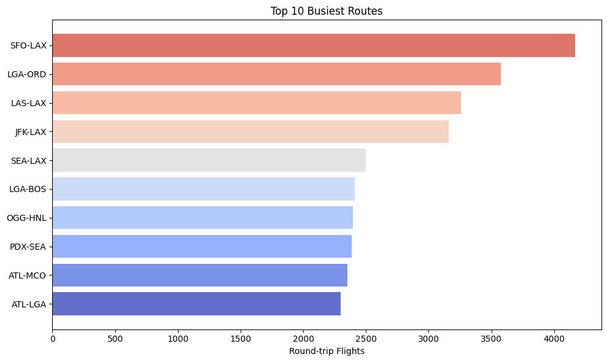

```
Top 10 routes make up 3% of all flights
```

```python
# Chart for top 10 busiest routes
routes = [f"{row['ORIGIN_flight']}-{row['DESTINATION_flight']}" for _, row in top_10_busy.iterrows()]
counts = top_10_busy['ROUNDTRIP_FLIGHT_COUNT'].values
colors = plt.cm.coolwarm(np.linspace(0.9, 0, len(routes)))

plt.figure(figsize=(10, 6))
plt.barh(routes, counts, color=colors, alpha=0.8)
plt.xlabel('Round-trip Flights')
plt.title('Top 10 Busiest Routes')
plt.gca().invert_yaxis()
plt.tight_layout()
plt.show()

print(f"Top 10 routes make up {counts.sum()/final_dataset['ROUNDTRIP_FLIGHT_COUNT'].sum()*100:.0f}% of all flights")
```

Based on the graph, we could clearly see that the top 10 busiest routes. The first one is from the San Francisco Internation to Los Angeles International.

# Task 2: Most Profitable Round-trip Route Analysis

Based on the given cost and revenue structure, calculate the 10 most profitable round-trip routes within quarters (excluding aircraft upfront purchase costs)

Cost Structure:

- **Fuel, oil, maintenance, crew costs**: $8 per mile
- **Depreciation, insurance, and others**: $1.18 per mile
- **Airport operating costs**: Medium airports $5,000, Large airports $10,000 (per landing fee, round-trip flights charged twice)
- **Delay costs**: For departure/arrival delays exceeding 15 minutes, $75 per minute

Revenue Structure:

- **Ticket revenue**: Based on ticket price and passenger count
- **Baggage fees**: 50% of passengers check 1 bag, $35 per segment, $70 total for round-trip
- **Maximum capacity**: 200 people per aircraft, actual passenger count calculated based on flight occupancy rate

## Approach one: Use the **total profit of each route within this period** as the determining factor for this question.

```python
# Profit analysis
print("Analyzing most profitable round-trip routes")
print("=" * 50)
# Cost and revenue parameters
COST_PER_MILE = 9.18
LARGE_AIRPORT_FEE = 10000
MEDIUM_AIRPORT_FEE = 5000
DELAY_COST = 75
FREE_DELAY = 15
MAX_CAPACITY = 200
BAGGAGE_FEE = 70

def calculate_profits(data):
    df = data.copy()

    # Calculate passengers and revenue
    df['passengers_per_flight'] = df['AVG_OCCUPANCY_RATE'] * MAX_CAPACITY
    df['total_passengers'] = df['passengers_per_flight'] * df['FLIGHT_COUNT']

    # Revenue calculation
    df['ticket_revenue'] = (df['AVG_FARE'] / 2) * df['total_passengers']
    df['baggage_revenue'] = 0.5 * BAGGAGE_FEE * df['total_passengers']
    df['total_revenue'] = df['ticket_revenue'] + df['baggage_revenue']

    # Cost calculation
    df['flight_costs'] = COST_PER_MILE * df['DISTANCE'] * df['FLIGHT_COUNT']

    # Airport fees
    origin_fee = df['ORIGIN_TYPE_flight'].map({'large_airport': LARGE_AIRPORT_FEE, 'medium_airport': MEDIUM_AIRPORT_FEE})
    dest_fee = df['DEST_TYPE_flight'].map({'large_airport': LARGE_AIRPORT_FEE, 'medium_airport': MEDIUM_AIRPORT_FEE})
    df['airport_fees'] = (origin_fee + dest_fee) * df['FLIGHT_COUNT']

    # Delay costs
    excess_dep = (df['AVG_DEP_DELAY'] - FREE_DELAY).clip(lower=0)
    excess_arr = (df['AVG_ARR_DELAY'] - FREE_DELAY).clip(lower=0)
    df['delay_costs'] = (excess_dep + excess_arr) * DELAY_COST * df['FLIGHT_COUNT']

    # Final profit calculation
    df['total_costs'] = df['flight_costs'] + df['airport_fees'] + df['delay_costs']
    df['profit'] = df['total_revenue'] - df['total_costs']
    df['profit_margin'] = (df['profit'] / df['total_revenue'] * 100).round(1)

    # Round-trip metrics
    df['roundtrips'] = df['FLIGHT_COUNT'] / 2
    df['profit_per_roundtrip']   = df['profit'] / df['roundtrips']

    return df

df_with_financials = calculate_profits(final_dataset)
top_10_routes = df_with_financials.sort_values('profit', ascending=False).head(10)

for i, (_, route) in enumerate(top_10_routes.iterrows(), 1):
    route_name = f"{route['ORIGIN_flight']} ↔ {route['DESTINATION_flight']}"

    print(f"\n{i:2d}. {route_name} ({route['YEAR']} Q{route['QUARTER']})")
    print(f"    Quarterly Profit: ${route['profit']:,.0f} (Profit margin: {route['profit_margin']:.1f}%)")
    print(f"    {route['roundtrips']:,.0f} roundtrips | {route['AVG_OCCUPANCY_RATE']:.1%} occupancy")
    print(f"    Revenue: ${route['total_revenue']:,.0f} = Tickets ${route['ticket_revenue']:,.0f} + Baggage ${route['baggage_revenue']:,.0f}")
    print(f"    Costs: ${route['total_costs']:,.0f} = Operations ${route['flight_costs']:,.0f} + Airport ${route['airport_fees']:,.0f} + Delays ${route['delay_costs']:,.0f}")
```

```
Analyzing most profitable round-trip routes
==================================================

 1. JFK ↔ LAX (2019 Q1)
    Quarterly Profit: $151,575,852 (Profit margin: 36.0%)
    3,160 roundtrips | 65.0% occupancy
    Revenue: $421,569,412 = Tickets $392,810,122 + Baggage $28,759,290
    Costs: $269,993,560 = Operations $143,593,560 + Airport $126,400,000 + Delays $0

 2. SFO ↔ EWR (2019 Q1)
    Quarterly Profit: $74,202,697 (Profit margin: 41.0%)
    1,212 roundtrips | 65.0% occupancy
    Revenue: $180,941,073 = Tickets $169,913,483 + Baggage $11,027,590
    Costs: $106,738,376 = Operations $57,077,201 + Airport $48,480,000 + Delays $1,181,175

 3. TWF ↔ SLC (2019 Q1)
    Quarterly Profit: $72,497,293 (Profit margin: 88.2%)
    291 roundtrips | 66.8% occupancy
    Revenue: $82,162,276 = Tickets $79,440,676 + Baggage $2,721,600
    Costs: $9,664,983 = Operations $934,983 + Airport $8,730,000 + Delays $0

 4. SFO ↔ JFK (2019 Q1)
    Quarterly Profit: $59,912,389 (Profit margin: 26.9%)
    1,860 roundtrips | 65.0% occupancy
    Revenue: $222,765,769 = Tickets $205,839,069 + Baggage $16,926,700
    Costs: $162,853,380 = Operations $88,334,605 + Airport $74,420,000 + Delays $98,775

 5. CLT ↔ FLO (2019 Q1)
    Quarterly Profit: $59,611,358 (Profit margin: 88.1%)
    252 roundtrips | 64.9% occupancy
    Revenue: $67,629,403 = Tickets $65,341,313 + Baggage $2,288,090
    Costs: $8,018,045 = Operations $458,045 + Airport $7,560,000 + Delays $0

 6. CLT ↔ GSP (2019 Q1)
    Quarterly Profit: $47,214,507 (Profit margin: 59.6%)
    774 roundtrips | 65.0% occupancy
    Revenue: $79,219,617 = Tickets $72,185,317 + Baggage $7,034,300
    Costs: $32,005,110 = Operations $1,065,110 + Airport $30,940,000 + Delays $0

 7. DCA ↔ ORD (2019 Q1)
    Quarterly Profit: $46,585,649 (Profit margin: 33.0%)
    1,848 roundtrips | 64.8% occupancy
    Revenue: $141,244,750 = Tickets $124,486,260 + Baggage $16,758,490
    Costs: $94,659,101 = Operations $20,759,101 + Airport $73,900,000 + Delays $0

 8. DCA ↔ LGA (2019 Q1)
    Quarterly Profit: $44,717,067 (Profit margin: 37.7%)
    1,680 roundtrips | 65.3% occupancy
    Revenue: $118,495,890 = Tickets $103,151,050 + Baggage $15,344,840
    Costs: $73,778,823 = Operations $6,598,823 + Airport $67,180,000 + Delays $0

 9. CLT ↔ ILM (2019 Q1)
    Quarterly Profit: $44,147,392 (Profit margin: 64.3%)
    732 roundtrips | 65.6% occupancy
    Revenue: $68,610,402 = Tickets $61,883,892 + Baggage $6,726,510
    Costs: $24,463,010 = Operations $2,488,010 + Airport $21,975,000 + Delays $0

10. CLT ↔ GSO (2019 Q1)
    Quarterly Profit: $42,314,599 (Profit margin: 57.8%)
    744 roundtrips | 65.1% occupancy
    Revenue: $73,187,604 = Tickets $66,410,974 + Baggage $6,776,630
    Costs: $30,873,005 = Operations $1,133,005 + Airport $29,740,000 + Delays $0
```

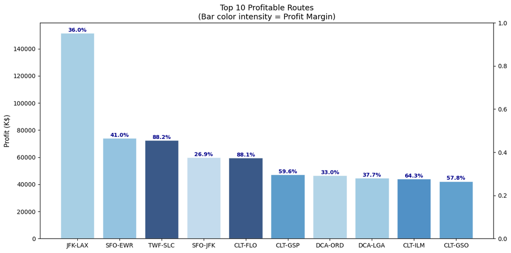

```python
# Visualization for Task 2
route_names = [f"{row['ORIGIN_flight']}-{row['DESTINATION_flight']}" for _, row in top_10_routes.iterrows()]
profit = top_10_routes['profit'].values / 1000
profit_margin = top_10_routes['profit_margin'].values

fig, ax1 = plt.subplots(figsize=(12, 6))
ax2 = ax1.twinx()
colors = plt.cm.Blues(profit_margin / profit_margin.max())
bars = ax1.bar(range(len(route_names)), profit, color=colors, alpha=0.8, edgecolor='white', linewidth=1)
ax1.set_ylabel('Profit (K$)', fontsize=11)

for i, (bar, margin) in enumerate(zip(bars, profit_margin)):
    height = bar.get_height()
    ax1.text(bar.get_x() + bar.get_width()/2., height + 50,
             f'{margin:.1f}%', ha='center', va='bottom',
             fontsize=9, fontweight='bold', color='darkblue')

plt.xticks(range(len(route_names)), route_names, rotation=45, ha='right')
plt.title('Top 10 Profitable Routes\n(Bar color intensity = Profit Margin)', fontsize=13)
plt.tight_layout()
plt.show()
```

## Approach 2: Use the Average profit per aircraft on a specific route within a quarter

- My chosen metric:

**The average profit earned by a single aircraft on a specific route within one quarter**

(This accounts for flight frequency × profit per flight.)

- Reasons: There could be multiple flights for an aircraft within a certain period. Even if a plane makes good profit on a single flight, that doesn’t account for the frequency of flights within the period
- Three layers of thinking for this question:
  1. Average profit per flight for a single aircraft:
  - This doesn’t account for how often the plane flies.
  - A plane might earn a lot on one flight, but if the turnaround time is long, its total profit over a period could still be low. So this view doesn’t reflect operational efficiency or true profitability.

  2. Average profit per aircraft on a route within a quarter
  - This layer is more balanced. It combines how much profit each flight generates and how often the plane flies.
  - For example:
    - Plane A earns $10,000 per flight and flies 20 times → $200,000 total
    - Plane B earns $20,000 per flight but only flies 5 times → $100,000 total
  - By taking both of these two factors into consideration, we could clearly see what's the goal to reach for investment purpose.

  3. Total route profit:
  - This includes the sum of all profits from flights along the route during the period.
  - A route may have many flights, and the total route profit is high, but if individual flight profits are low, the average per aircraft may still be unimpressive.
  - From a strategic perspective, we could use this metrics in the long run to help the company decide whether to increase investement in certain routes. However, it may mask individual aircraft efficiency.
- Assumptions:
- Calculations are as below.

```python
# Aircraft Profitability Analysis by Tail Number
print("Aircraft Profitability Analysis by Tail Number")
print("=" * 60)

# Aggregate data by aircraft and route
flights_by_aircraft = flights_df.groupby(['YEAR', 'QUARTER', 'ROUTE_ID', 'TAIL_NUM']).agg({
    'ORIGIN': 'first',
    'DESTINATION': 'first',
    'DISTANCE': 'first',
    'AIR_TIME': 'mean',
    'DEP_DELAY': 'mean',
    'ARR_DELAY': 'mean',
    'OCCUPANCY_RATE': 'mean',
    'FL_DATE': 'count'
}).rename(columns={
    'FL_DATE': 'FLIGHT_COUNT',
    'AIR_TIME': 'AVG_AIR_TIME',
    'DEP_DELAY': 'AVG_DEP_DELAY',
    'ARR_DELAY': 'AVG_ARR_DELAY',
    'OCCUPANCY_RATE': 'AVG_OCCUPANCY_RATE'
}).reset_index()

print(f"Aircraft-route combinations: {len(flights_by_aircraft):,}")
print(f"Unique aircraft: {flights_by_aircraft['TAIL_NUM'].nunique():,}")
print(f"Unique routes: {flights_by_aircraft['ROUTE_ID'].nunique():,}")
```

```
Aircraft Profitability Analysis by Tail Number
============================================================
Aircraft-route combinations: 484,121
Unique aircraft: 6,009
Unique routes: 2,808
```

```python
# Constants
MAX_CAPACITY = 200
BAGGAGE_FEE = 70
COST_PER_MILE = 9.18
LARGE_AIRPORT_FEE = 10000
MEDIUM_AIRPORT_FEE = 5000
DELAY_COST = 75
FREE_DELAY = 15

# Step 1: 完整计算每架飞机在每条航线上的利润
def calculate_aircraft_profits(data):
    df = data.copy()

    # Revenue
    df['passengers_per_flight'] = df['AVG_OCCUPANCY_RATE'] * MAX_CAPACITY
    df['ticket_revenue'] = (df['AVG_FARE'] / 2) * df['passengers_per_flight']
    df['baggage_revenue'] = 0.5 * BAGGAGE_FEE * df['passengers_per_flight']
    df['total_revenue'] = (df['ticket_revenue'] + df['baggage_revenue'])

    # Flight cost
    df['flight_costs'] = COST_PER_MILE * df['DISTANCE']

    return df

def calculate_complete_aircraft_profits(data):
    df = calculate_aircraft_profits(data)

    # Airport fees
    origin_fee = df['ORIGIN_TYPE'].map({'large_airport': LARGE_AIRPORT_FEE, 'medium_airport': MEDIUM_AIRPORT_FEE})
    dest_fee = df['DEST_TYPE'].map({'large_airport': LARGE_AIRPORT_FEE, 'medium_airport': MEDIUM_AIRPORT_FEE})
    df['airport_fees'] = origin_fee + dest_fee

    # Delay costs
    excess_dep = (df['AVG_DEP_DELAY'] - FREE_DELAY).clip(lower=0)
    excess_arr = (df['AVG_ARR_DELAY'] - FREE_DELAY).clip(lower=0)
    df['delay_costs'] = (excess_dep + excess_arr) * DELAY_COST

    # Final profit
    df['total_costs'] = df['flight_costs'] + df['airport_fees'] + df['delay_costs']
    df['profit'] = (df['total_revenue'] - df['total_costs'])* df['FLIGHT_COUNT']# 单次飞行利润
    df['profit_margin'] = (df['profit'] / df['total_revenue'] * 100).round(1)

    return df

# Step 2: Merge airport info
# Merge aircraft data with only AVG_FARE from tickets_agg
aircraft_tickets = flights_by_aircraft.merge(
    tickets_agg[['YEAR', 'QUARTER', 'ROUTE_ID', 'AVG_FARE']],
    on=['YEAR', 'QUARTER', 'ROUTE_ID'],
    how='left')

aircraft_enhanced = aircraft_tickets.merge(
    airports_df[['IATA_CODE', 'TYPE']].rename(columns={'IATA_CODE': 'ORIGIN', 'TYPE': 'ORIGIN_TYPE'}),
    on='ORIGIN', how='left'
).merge(
    airports_df[['IATA_CODE', 'TYPE']].rename(columns={'IATA_CODE': 'DESTINATION', 'TYPE': 'DEST_TYPE'}),
    on='DESTINATION', how='left'
)

# Step 3: Run profit calculation
aircraft_profits = calculate_complete_aircraft_profits(aircraft_enhanced)

# Step 4: Route-level analysis - average aircraft profit
route_profit_summary = aircraft_profits.groupby(
    ['YEAR', 'QUARTER', 'ROUTE_ID', 'ORIGIN', 'DESTINATION']
)['profit'].mean().reset_index()

route_profit_summary.rename(columns={'profit': 'avg_aircraft_profit_per_flight'}, inplace=True)

# Step 5: Get Top 10 routes
top_10_routes = route_profit_summary.sort_values(
    by='avg_aircraft_profit_per_flight',
    ascending=False
).head(10)

# Step 6: Display results
print("\n=== Top 10 Most Profitable Routes (Avg Profit per Aircraft per Flight) ===")

for i, (_, route) in enumerate(top_10_routes.iterrows(), 1):
    route_name = f"{route['ORIGIN']} ↔ {route['DESTINATION']}"
    print(f"\n{i:2d}. {route_name} ({route['YEAR']} Q{route['QUARTER']})")
    print(f"    Avg Profit per Aircraft per Flight: ${route['avg_aircraft_profit_per_flight']:,.0f}")
```

```
=== Top 10 Most Profitable Routes (Avg Profit per Aircraft per Flight) ===

 1. OGG ↔ HNL (2019 Q1)
    Avg Profit per Aircraft per Flight: $1,609,909

 2. HNL ↔ JHM (2019 Q1)
    Avg Profit per Aircraft per Flight: $1,405,549

 3. ATL ↔ EYW (2019 Q1)
    Avg Profit per Aircraft per Flight: $1,403,711

 4. HNL ↔ MKK (2019 Q1)
    Avg Profit per Aircraft per Flight: $1,318,368

 5. CLT ↔ FLO (2019 Q1)
    Avg Profit per Aircraft per Flight: $1,149,530

 6. SLC ↔ TWF (2019 Q1)
    Avg Profit per Aircraft per Flight: $1,068,918

 7. IAH ↔ ASE (2019 Q1)
    Avg Profit per Aircraft per Flight: $1,032,619

 8. HNL ↔ OGG (2019 Q1)
    Avg Profit per Aircraft per Flight: $1,027,515

 9. KOA ↔ HNL (2019 Q1)
    Avg Profit per Aircraft per Flight: $861,125

10. SLC ↔ PIH (2019 Q1)
    Avg Profit per Aircraft per Flight: $837,713
```

# Task 3: Investment Recommendation: Top 5 Most Worthy Round-trip Routes for Investment

Based on a core business metrics investment scoring model, I consider

- **Profitability** (50%): Absolute profit and profit margin
- **Market Performance** (30%): Flight frequency and Occupancy rate
- **Operational Efficiency** (20%): delay control

```python
# Task 3: Investment Recommendation Analysis
def calculate_investment_score(routes_data):
    df = routes_data.copy()

    # Normalize to 0-100 scale
    for col in ['profit', 'profit_margin', 'FLIGHT_COUNT', 'AVG_OCCUPANCY_RATE']:
        df[f'{col}_score'] = (df[col] - df[col].min()) / (df[col].max() - df[col].min()) * 100

    # For delay metrics - invert the scale (lower delay = higher score)
    for col in ['AVG_DEP_DELAY', 'AVG_ARR_DELAY']:
        df[f'{col}_score'] = 100 - ((df[col] - df[col].min()) / (df[col].max() - df[col].min()) * 100)

    # Investment score calculation
    df['investment_score'] = (
        (df['profit_score'] * 0.3 + df['profit_margin_score'] * 0.2) +
        (df['FLIGHT_COUNT_score'] * 0.15 + df['AVG_OCCUPANCY_RATE_score'] * 0.15) +
        (df['AVG_DEP_DELAY_score'] * 0.1 + df['AVG_ARR_DELAY_score'] * 0.1)
    )
    return df

scored_routes = calculate_investment_score(df_with_financials)
top_5_investments = scored_routes.sort_values('investment_score', ascending=False).head(5)

print("Top 5 recommended routes for investment")
for rank, (_, r) in enumerate(top_5_investments.iterrows(), 1):
    print(f"{rank}. {r['ORIGIN_flight']}-{r['DESTINATION_flight']}: Score {r['investment_score']:.1f} | "
          f"Profit ${r['profit']:,.0f} ({r['profit_margin']:.1f}%) | {r['FLIGHT_COUNT']:,} flights")
```

[output not shown]

[figure not shown]

```python
# Simple visualization for Task 3
route_names = [f"{row['ORIGIN_flight']}-{row['DESTINATION_flight']}" for _, row in top_5_investments.iterrows()]
scores = top_5_investments['investment_score'].values
fig, (ax1) = plt.subplots(figsize=(13, 6))

colors = plt.cm.coolwarm(np.linspace(0.9, 0.2, len(route_names)))
ax1.bar(route_names, scores, color=colors, alpha=0.8)
ax1.set_xlabel('Routes')
ax1.set_ylabel('Investment Score')
ax1.set_title('Top 5 Routes Investment Scores')
ax1.tick_params(axis='x', rotation=45)

for i, (bar, score) in enumerate(zip(bars, scores)):
    ax1.text(bar.get_x() + bar.get_width()/2., bar.get_height() + 1,
             f'{score:.1f}', ha='center', va='bottom')
```

# Task 4: Breakeven Analysis for Top 5 Investment Routes

```python
# Task 4: Breakeven Analysis for Top 5 Investment Routes
print("Task 4: Breakeven Analysis")
print("-" * 50)

# Aircraft cost
AIRCRAFT_COST = 90_000_000  # $90 million per aircraft

print(f"Aircraft Cost: ${AIRCRAFT_COST:,}")
print()

# Calculate breakeven for each route
for i, (_, route) in enumerate(top_5_investments.iterrows(), 1):
    route_name = f"{route['ORIGIN_flight']}-{route['DESTINATION_flight']}"

    # Basic calculations
    total_profit = route['profit']
    total_flights = route['FLIGHT_COUNT']
    profit_per_flight = total_profit / total_flights

    # Breakeven calculations
    breakeven_flights = AIRCRAFT_COST / profit_per_flight

    # Print results
    print(f"{i}. {route_name}")
    print(f"   Profit per flight: ${profit_per_flight:,.0f}")
    print(f"   Flights needed to breakeven: {breakeven_flights:,.0f}")
```

[output not shown]

# Task 5: KPIs

```python
import statsmodels.api as sm
from statsmodels.formula.api import ols
rounds_summary = df_with_financials.copy()
rounds_summary['profit_per_flight'] = rounds_summary['profit'] / rounds_summary['FLIGHT_COUNT']
rounds_summary['rounds_count'] = rounds_summary['FLIGHT_COUNT'] / 2
rounds_summary['otp'] = 1 - ((rounds_summary['AVG_DEP_DELAY'] > 15).astype(int) + (rounds_summary['AVG_ARR_DELAY'] > 15).astype(int)) / 2
rounds_summary['route_density'] = rounds_summary['FLIGHT_COUNT'] / rounds_summary['DISTANCE']  # 航线密度
rounds_summary['avg_fare_per_mile'] = rounds_summary['AVG_FARE'] / rounds_summary['DISTANCE']  # 每英里票价
rounds_summary['large_airport'] = ((rounds_summary['ORIGIN_TYPE_flight'] == 'large_airport') |
                                  (rounds_summary['DESTINATION_TYPE_flight'] == 'large_airport')).astype(int)  # 大型机场指示变量

X = rounds_summary[['rounds_count','AVG_DEP_DELAY','AVG_AIR_TIME','DISTANCE','AVG_OCCUPANCY_RATE',
                   'otp','route_density','avg_fare_per_mile',
                   'large_airport']]
X = sm.add_constant(X)
y = rounds_summary.profit_per_flight


model = sm.OLS(y,X)
res = model.fit()
res.summary()
```

OLS Regression Results

[output not shown]

[output not shown]

| Omnibus: | 234.617 | Durbin-Watson: | 1.482 |
| --- | --- | --- | --- |
| Prob(Omnibus): | 0.000 | Jarque-Bera (JB): | 1038.698 |
| Skew: | 0.289 | Prob(JB): | 2.82e-226 |
| Kurtosis: | 5.933 | Cond. No. | 7.12e+04 |

Notes:  
[1] Standard Errors assume that the covariance matrix of the errors is correctly specified.  
[2] The condition number is large, 7.12e+04. This might indicate that there are  
strong multicollinearity or other numerical problems.

Number of Flights: An increase in the number of flights for a specific route consistently leads to an improvement in profit_per_flight.

Average Occupancy: High occupancy levels positively impact profit, suggesting that fuller flights tend to result in higher profit_per_flight.

After conducting research and reviewing relevant papers on the airline industry, we have identified the following key performance indicators (KPIs) that can be monitored in the future to gauge the success of round-trip routes:

- Revenue per Available Seat Mile (RASM): This metric directly measures the profitability of round-trip routes.
- On-Time Performance (OTP): This KPI assesses the punctuality of flights by tracking the proportion of flights that arrive on schedule.
- Average Departure and Arrival Delay Minutes: Tracking departure and arrival delays separately provides a comprehensive view of the route's punctuality.
- Flight Occupancy Rate: A high occupancy rate indicates that a significant portion of the airline's tickets are being sold, leading to increased revenue.
- Number of Flights in the Route Market: Monitoring market demand through the number of flights can directly impact revenue, as higher demand often leads to increased earnings.
- Cancellation Rate: This KPI reflects the operational situation and the reliability of the route.
- Mishandled Baggage Rate: Tracking the rate of mishandled baggage is crucial for assessing the efficiency of baggage management.
- Customer Retention Rate: Understanding what keeps customers with your company is essential. A high customer retention rate indicates customer satisfaction and loyalty while also highlighting areas for potential improvements in customer service.